# Final Assignment

Yousuf Ahmed Nahian (202509052)

2025-11-29

# Solution to Q.A

```r
data("flights")

flights_weekly <- flights |>
  mutate(
    date = make_date(year, month, day),
    week = floor_date(date, unit = "week"),
    is_cancelled = is.na(dep_delay),
    is_late = dep_delay > 15
  ) |>
  group_by(week) |>
  summarise(
    mean_delay = mean(dep_delay, na.rm = TRUE),
    median_delay = median(dep_delay, na.rm = TRUE),
    late_rate = mean(is_late, na.rm = TRUE),
    cancel_rate = mean(is_cancelled),
    n_flights = n()
  ) |>
  ungroup()
```

```r
flights_weekly_long <- flights_weekly |>
  select(week, mean_delay, late_rate, cancel_rate) |>
  pivot_longer(
    cols = -week,
    names_to = "measure",
    values_to = "value"
  )
```

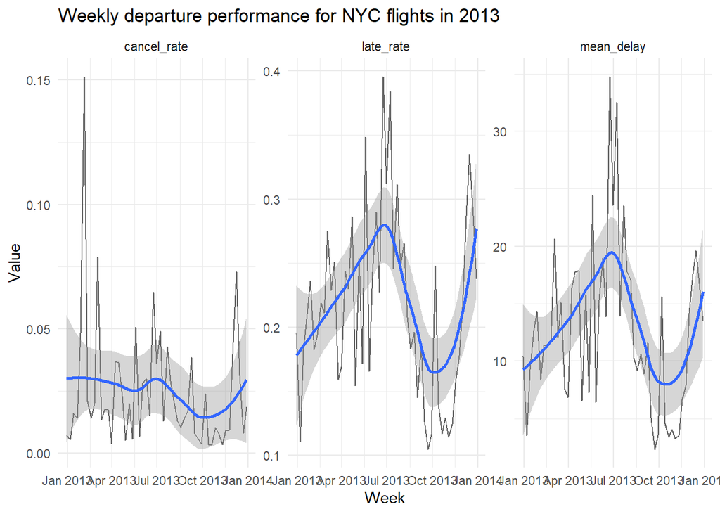

```r
ggplot(flights_weekly_long, aes(x = week, y = value)) +
  geom_line(alpha = 0.6) +
  geom_smooth(se = TRUE) +
  facet_wrap(~ measure, scales = "free_y") +
  labs(
    title = "Weekly departure performance for NYC flights in 2013",
    x = "Week",
    y = "Value",
  ) +
  theme_minimal()
```

# Conclusion

Delays clearly increase during the middle of the year, with both mean delay and late departures peaking in summer. Cancellation rates stay low most weeks but show a few sharp spikes, mostly early in the year. Overall, delays and late follow a smoother seasonal trend, while cancellations are more irregular.

# Solution to Q.B

```r
imdb_path <- "C:/Users/yousu/Downloads/IMDb"

title_basics <- read_tsv(
  file.path(imdb_path, "title.basics.tsv.gz"),
  na = "\\N",
  col_select = c(tconst, primaryTitle, startYear)
)

title_ratings <- read_tsv(
  file.path(imdb_path, "title.ratings.tsv.gz"),
  na = "\\N",
  col_select = c(tconst, averageRating)
)

title_principals <- read_tsv(
  file.path(imdb_path, "title.principals.tsv.gz"),
  na = "\\N",
  col_select = c(tconst, nconst, category)
)

name_basics <- read_tsv(
  file.path(imdb_path, "name.basics.tsv.gz"),
  na = "\\N",
  col_select = c(nconst, primaryName)
)
```

```r
check_relation <- function(primary_df, primary_key, foreign_df, foreign_key) {

  missing_values <- sum(!foreign_df[[foreign_key]] %in% primary_df[[primary_key]])

  if(missing_values == 0) {
    return(TRUE)
  } else {
    return(FALSE)
  }
}
```

```r
rel1 <- check_relation(title_basics, "tconst", title_ratings, "tconst")

rel2 <- check_relation(title_basics, "tconst", title_principals, "tconst")

rel3 <- check_relation(name_basics, "nconst", title_principals, "nconst")
```

```r
sum(!title_principals$tconst %in% title_basics$tconst)
```

```
## [1] 15189
```

```r
sum(!title_principals$nconst %in% name_basics$nconst)
```

```
## [1] 4267
```

```r
missing_movies <- title_principals %>%
  filter(!tconst %in% title_basics$tconst) %>%
  head(10)

missing_movies
```

```
## # A tibble: 10 × 3
##    tconst    nconst     category
##    <chr>     <chr>      <chr>
##  1 tt2175549 nm2721209  actress
##  2 tt2175549 nm0316379  actor
##  3 tt2175549 nm4847686  actor
##  4 tt2175549 nm16530555 self
##  5 tt2175549 nm2807036  actor
##  6 tt2175549 nm3083426  actor
##  7 tt2175549 nm0191760  actor
##  8 tt2175549 nm5098011  actor
##  9 tt2175549 nm1800847  actress
## 10 tt2175549 nm2609373  actor
```

```r
missing_people <- title_principals %>%
  filter(!nconst %in% name_basics$nconst) %>%
  head(10)

missing_people
```

```
## # A tibble: 10 × 3
##    tconst    nconst     category
##    <chr>     <chr>      <chr>
##  1 tt0022647 nm17757978 actor
##  2 tt0027126 nm17757976 actor
##  3 tt0027126 nm17757973 actress
##  4 tt0027126 nm17757974 actor
##  5 tt0027126 nm17757977 actor
##  6 tt0029339 nm17757980 actress
##  7 tt0073261 nm17928486 editor
##  8 tt0104973 nm17929725 actor
##  9 tt0104973 nm17929726 actor
## 10 tt0117917 nm17757689 self
```

```r
directors_data <- title_principals %>%
  filter(category == "director") %>%
  left_join(title_ratings, by = "tconst") %>%
  left_join(name_basics, by = "nconst")
```

```r
director_scores <- directors_data %>%
  filter(!is.na(averageRating)) %>%
  group_by(primaryName) %>%
  summarise(
    avg_rating = mean(averageRating),
    movies = n()
  ) %>%
  filter(movies >= 5) %>%
  arrange(desc(avg_rating))
```

[figure not shown]

```r
top_directors <- director_scores %>% slice_max(avg_rating, n = 20)

ggplot(top_directors, aes(x = avg_rating, y = reorder(primaryName, avg_rating))) +
  geom_col(fill = "lightblue") +
  labs(title="Top Directors by IMDb Rating (5+ movies)",
       x="Average Rating", y="Director") +
  theme_minimal()
```

# Conclsuion

I evaluated three primary-foreign key relationships in the IMDb dataset. title.basics → title.ratings was valid, confirming that every rated movie exists in the main movie table.

In contrast, title.basics → title_principals and name.basics → title_principals failed, with 15,189 titles and 4,267 people missing. This is likely because IMDb principals includes TV episodes, short films and incomplete entries that are not present in the other tables.

I then analyzed movie quality by focusing on directors, using the IMDb average rating as my metric. After merging tables and grouping by director, i calculated the average rating for all directors with at least five movies revealing clear differences in quality across individuals. Some directors consistently achieve high ratings, while others score significantly lower.

# Solution to Q.C

```r
plots <- read.csv("wiki_movie_plots.csv")
names(plots)
```

```
## [1] "Release.Year"     "Title"            "Origin.Ethnicity" "Director"
## [5] "Cast"             "Genre"            "Wiki.Page"        "Plot"
```

```r
plots2 <- plots %>%
  rename(primaryTitle = Title,
         startYear    = Release.Year)
```

```r
relation_plots_imdb <- check_relation(
  primary_df = title_basics, primary_key = "primaryTitle",
  foreign_df = plots2,       foreign_key = "primaryTitle"
)

relation_plots_imdb
```

```
## [1] FALSE
```

```r
sum(!plots2$primaryTitle %in% title_basics$primaryTitle)
```

```
## [1] 4344
```

```r
movie_join <- title_basics %>%
  left_join(plots2,        by = c("primaryTitle", "startYear")) %>%
  left_join(title_ratings, by = "tconst")
```

```r
words <- movie_join %>%
  select(tconst, primaryTitle, averageRating, Plot) %>%
  unnest_tokens(word, Plot)

sent <- get_sentiments("afinn")

movie_sentiment <- words %>%
  inner_join(sent, by="word") %>%
  group_by(tconst, primaryTitle, averageRating) %>%
  summarise(sentiment_score = mean(value), .groups="drop")
```

[figure not shown]

```r
ggplot(movie_sentiment, aes(x = averageRating, y = sentiment_score)) +
  geom_point(alpha = 0.3) +
  geom_smooth() +
  labs(title = "Sentiment Score vs IMDb Rating",
       x = "IMDb Rating",
       y = "Average Plot Sentiment Score") +
  theme_minimal()
```

# Conclusion

The wiki_movie_plots dataset can be joined with IMDb using Title and Release Year. Testing showed that matching only by Title returned FALSE, with 4,344 movies not linking between datasets. This indicates an imperfect relationship due to alternate titles, missing entries, remakes, and inconsistent year information. joining by both title and Year improves linkage but still loses films.

Overall, the datasets link reasonably but not perfectly, and sentiment appears weakly correlated with movie rating.

# Solution to Q.D

```r
words <- movie_join %>%
  select(primaryTitle, startYear, Plot) %>%
  filter(!is.na(startYear)) %>%
  unnest_tokens(word, Plot)
```

```r
sent <- get_sentiments("afinn")

movie_sent_year <- words %>%
  inner_join(sent, by="word") %>%
  group_by(primaryTitle, startYear) %>%
  summarise(sentiment_score = mean(value), .groups="drop")
```

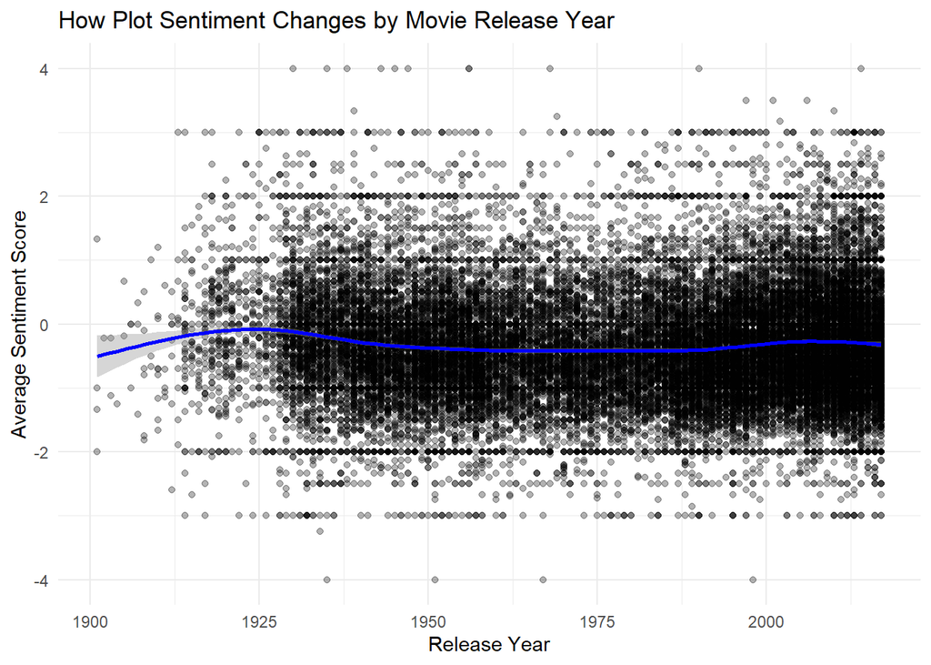

```r
ggplot(movie_sent_year, aes(x = startYear, y = sentiment_score)) +
  geom_point(alpha = 0.3) +
  geom_smooth(color="blue") +
  labs(title="How Plot Sentiment Changes by Movie Release Year",
       x="Release Year",
       y="Average Sentiment Score") +
  theme_minimal()
```

# Conclusion